# logistic_regression_assignment_ali_abid

Ali Abid

2024-11-03

# Introduction and Situational Context

Despite being the fifth most populous country in the world, Pakistan is only able to spend as much as 1.7 percent of its GDP on education (Abbasi, 2023). The tumultuous domestic political climate, in conjunction with the global geopolitical landscape, has undeniably resulted in a series of macroeconomic crises within the nation. These crises have unfortunately led to widespread inflation, a rise in poverty, and a profound literacy crisis that poses significant challenges for future generations. A sizable children population (around 26 million) remains out of school (Haider, 2024) which can have devastating impact on the opportunities of the country to grow out of these crises.

# Purpose

The purpose of this research project is to understand the schooling, household and climate change factors that contribute to predicting whether a student exhibits general knowledge or not. The dataset used in this analysis is the ASER 2023 rural dataset which is a household survey conducted in Pakistan to assess the learning levels of children in the country. The dataset contains information on the academic outcomes including whether a student exhibited general knowledge while being surveyed, the said students’ household characteristics, and the impact of climate change as reported by their households. The analysis will focus on the factors that contribute to the general knowledge of students in Pakistan and will use logistic regression to predict the outcome in a probabilistic form based on these predictors.

# Data

The dataset used in this analysis is the ASER 2023 dataset which is a household survey conducted in Pakistan to assess the learning levels of children in the rural side of the country. The first dataset `aser_child` contains information on the academic outcomes of the children including their educational status, grades, and reading levels. The second dataset `aser_household` contains information on the household characteristics including the number of earning members, the presence of a car or motorcycle, and the impact of climate change on the household. The two datasets are merged on the HouseholdId column to create a single dataset for analysis.

The variables of interest are: RNAME (Region Name), HouseholdCounter (People in a Household), EarningMembers (Earning Members in a Household), Car (Number of Cars in a Household if any), MotorCycle (Number of Cars in a Household if any), TravelTime (Time to School), ClimateChange (Climate Change Awareness), FloodImpacted (Impacted by Flood), EarningImpacted (Earning Impacted by Climate Change), PsychologicalImpacted (Psychologically Impacted by Climate Change), SchoolingAffected (Schooling Affected by Climate Change), LocalLangReadingLevel (Local Language Reading Level), ArithmeticLevel (Arithmetic Level), EnglishReadingLevel (English Reading Level), and GeneralKnowledge (Binary Variable showing whether a student exhibited General Knowledge while being tested or not).

**Predictor Variables**: HouseholdCounter, EarningMembers, TravelTime, Car, MotorCycle, TravelTime, ClimateChange, FloodImpacted, EarningImpacted, PsychologicalImpacted, SchoolingAffected, ArithmeticLevel, EnglishReadingLevel, LocalLangReadingLevel

**Outcome Variables**: GeneralKnowledge

# Research Question

What academic, household and climate change factors contribute to predicting whether a student exhibits general knowledge or not?

### Data Wrangling

Loading the required libraries and the datasets

```r
# Load the libraries
library(tidyverse)
library(readr)
library(caret)
library(psych)
library(ROSE)
# Load the data
aser_child <- read_csv("ITAASER2023Child.csv")
aser_household <- read_csv("ITAASER2023Household.csv") %>%
  rename(HHID = HouseholdId) # Renaming the HouseholdId column to HHID for merging with the Child Dataset
# Merging the two datasets
aser_child_household_data <- aser_child %>%
  left_join(aser_household, by = "HHID")
```

```r
# --- 1. Selecting Relevant Variables from Household-Level, and Child-Level Observations---
aser_child_household_data <- aser_child_household_data %>%
  select(
    # Dataset Identifiers
    RNAME,

    # Household Characteristics
    HouseholdCounter, EarningMembers, Car, MotorCycle,

    # Time to school
    TravelTime,

    # Climate Change Impact
    ClimateChange, FloodImpacted, EarningImpacted, PsychologicalImpacted, SchoolingAffected,

    # Child Characteristics - EducationalStatus, Grades, LocalLangReadingLevel, ArithmeticLevel, EnglishReadingLevel
    C15, C19, C20, C27
  ) %>%
  rename(

    # Child Characteristics - EducationalStatus, Grades, InstitutionType, LocalLangReadingLevel, ArithmeticLevel, EnglishReadingLevel
    LocalLangReadingLevel = C15, ArithmeticLevel = C19, EnglishReadingLevel = C20, GeneralKnolwedge = C27

  )
```

## Data Cleaning

Since our outcome variable is a binary, we are going to use logistic regression. For that, we need to scale the predictor variables so that their mean is zero and the values are standardized to the standard deviation from zero. We also need to remove the rows with missing values.Similarly, we are mutating the General Knowledge Score to a factor variable for the logistic regression model.

```r
# --- 2. Data Cleaning ---
# Removing the rows with missing values
aser_child_household_tib <- aser_child_household_data %>%
  select(-RNAME) %>% #remove RNAME
  na.omit() %>% #get rid of rows with NAs
  mutate(GeneralKnolwedge = as.factor(GeneralKnolwedge)) %>% #change GK Score to factor
  mutate_at(c(1:13), ~(scale(.) %>% as.vector))
  #scale all variables so mean is zero and values are standardized to SD from zero
  #as.vector ensures columns are vectors

library(psych)

psych::describe(aser_child_household_tib) #gives you a lot of descriptives quickly
```

```
##                       vars    n mean   sd median trimmed mad   min   max range
## HouseholdCounter         1 1494 0.00 1.00   0.02   -0.04 0.8 -1.18 14.65 15.83
## EarningMembers           2 1494 0.00 1.00  -0.05   -0.05 0.0 -0.05 22.16 22.21
## Car                      3 1494 0.00 1.00   0.17   -0.07 0.0 -1.02  9.61 10.62
## MotorCycle               4 1494 0.00 1.00   0.01   -0.03 0.0 -1.88  7.56  9.44
## TravelTime               5 1494 0.00 1.00  -0.81   -0.14 0.0 -0.81  1.96  2.77
## ClimateChange            6 1494 0.00 1.00  -0.04    0.01 1.8 -1.26  1.17  2.43
## FloodImpacted            7 1494 0.00 1.00   0.56    0.22 0.0 -2.29  0.56  2.85
## EarningImpacted          8 1494 0.00 1.00   0.62    0.21 0.0 -2.41  0.62  3.03
## PsychologicalImpacted    9 1494 0.00 1.00   0.62    0.20 0.0 -2.30  0.62  2.92
## SchoolingAffected       10 1494 0.00 1.00   0.56    0.22 0.0 -2.60  0.56  3.16
## LocalLangReadingLevel   11 1494 0.00 1.00   0.82    0.13 0.0 -3.64  0.82  4.47
## ArithmeticLevel         12 1494 0.00 1.00   0.79    0.16 0.0 -3.61  0.79  4.41
## EnglishReadingLevel     13 1494 0.00 1.00   0.77    0.07 0.0 -1.30  0.77  2.07
## GeneralKnolwedge*       14 1494 1.72 0.45   2.00    1.78 0.0  1.00  2.00  1.00
##                        skew kurtosis   se
## HouseholdCounter       7.47    97.26 0.03
## EarningMembers        21.87   480.90 0.03
## Car                    5.04    42.42 0.03
## MotorCycle             0.81     5.49 0.03
## TravelTime             0.81    -0.68 0.03
## ClimateChange         -0.06    -1.52 0.03
## FloodImpacted         -1.49     0.65 0.03
## EarningImpacted       -1.39     0.50 0.03
## PsychologicalImpacted -1.28     0.09 0.03
## SchoolingAffected     -1.57     1.06 0.03
## LocalLangReadingLevel -0.99     0.23 0.03
## ArithmeticLevel       -1.09     0.20 0.03
## EnglishReadingLevel   -0.54    -1.71 0.03
## GeneralKnolwedge*     -1.00    -1.00 0.01
```

### Check for Multicollinearity

```r
cor(aser_child_household_tib[,c(1:13)]) #correlation matrix
```

```
##                       HouseholdCounter EarningMembers         Car  MotorCycle
## HouseholdCounter           1.000000000   -0.016264781 0.022136356 -0.04360623
## EarningMembers            -0.016264781    1.000000000 0.008700394  0.09269152
## Car                        0.022136356    0.008700394 1.000000000  0.32983275
## MotorCycle                -0.043606233    0.092691517 0.329832753  1.00000000
## TravelTime                 0.028301992    0.033455773 0.128197953  0.06311235
## ClimateChange              0.058074349   -0.051432228 0.049068733 -0.03800307
## FloodImpacted              0.045382016    0.027300084 0.111807374  0.16096585
## EarningImpacted            0.035844243   -0.104833459 0.113499218  0.14862880
## PsychologicalImpacted      0.048561966    0.029987601 0.158573316  0.16167265
## SchoolingAffected          0.045702326    0.027344486 0.106086996  0.12544311
## LocalLangReadingLevel     -0.008294421    0.021222455 0.076771515  0.14800727
## ArithmeticLevel           -0.051587203    0.023394353 0.085558562  0.15457119
## EnglishReadingLevel        0.010973016    0.006496107 0.094338027  0.15289999
##                        TravelTime ClimateChange FloodImpacted EarningImpacted
## HouseholdCounter       0.02830199    0.05807435   0.045382016      0.03584424
## EarningMembers         0.03345577   -0.05143223   0.027300084     -0.10483346
## Car                    0.12819795    0.04906873   0.111807374      0.11349922
## MotorCycle             0.06311235   -0.03800307   0.160965853      0.14862880
## TravelTime             1.00000000    0.12723522   0.043897976      0.12176483
## ClimateChange          0.12723522    1.00000000   0.295665200      0.22949231
## FloodImpacted          0.04389798    0.29566520   1.000000000      0.53691027
## EarningImpacted        0.12176483    0.22949231   0.536910272      1.00000000
## PsychologicalImpacted  0.08785255    0.38591323   0.707323911      0.42224545
## SchoolingAffected      0.04508734    0.32534389   0.669541831      0.37440761
## LocalLangReadingLevel  0.02181336   -0.07663077  -0.005455211      0.06468253
## ArithmeticLevel       -0.05128515   -0.14387956  -0.015854957      0.02623144
## EnglishReadingLevel    0.12178896   -0.02545546   0.068163731      0.10768841
##                       PsychologicalImpacted SchoolingAffected
## HouseholdCounter                0.048561966        0.04570233
## EarningMembers                  0.029987601        0.02734449
## Car                             0.158573316        0.10608700
## MotorCycle                      0.161672652        0.12544311
## TravelTime                      0.087852546        0.04508734
## ClimateChange                   0.385913234        0.32534389
## FloodImpacted                   0.707323911        0.66954183
## EarningImpacted                 0.422245450        0.37440761
## PsychologicalImpacted           1.000000000        0.74084426
## SchoolingAffected               0.740844262        1.00000000
## LocalLangReadingLevel           0.035887466       -0.03726657
## ArithmeticLevel                 0.007884654       -0.03183389
## EnglishReadingLevel             0.097177148        0.05253087
##                       LocalLangReadingLevel ArithmeticLevel EnglishReadingLevel
## HouseholdCounter               -0.008294421    -0.051587203         0.010973016
## EarningMembers                  0.021222455     0.023394353         0.006496107
## Car                             0.076771515     0.085558562         0.094338027
## MotorCycle                      0.148007270     0.154571192         0.152899988
## TravelTime                      0.021813358    -0.051285148         0.121788957
## ClimateChange                  -0.076630769    -0.143879564        -0.025455462
## FloodImpacted                  -0.005455211    -0.015854957         0.068163731
## EarningImpacted                 0.064682525     0.026231442         0.107688415
## PsychologicalImpacted           0.035887466     0.007884654         0.097177148
## SchoolingAffected              -0.037266569    -0.031833888         0.052530867
## LocalLangReadingLevel           1.000000000     0.638980824         0.651015203
## ArithmeticLevel                 0.638980824     1.000000000         0.540789283
## EnglishReadingLevel             0.651015203     0.540789283         1.000000000
```

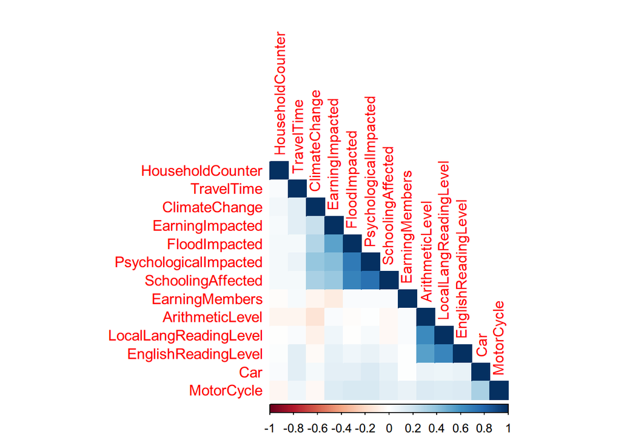

```r
corrplot::corrplot(cor(aser_child_household_tib[,c(1:13)]), method = "color", type = "lower", order = "hclust") #correlation plot, threshold for removing is 0.6
```

### Removing Highly Correlated Variables

```r
# Removing highly correlated variables
aser_child_household_tib <- aser_child_household_tib %>%
  select(-LocalLangReadingLevel, -ArithmeticLevel, -EnglishReadingLevel, -FloodImpacted, -SchoolingAffected, -EarningImpacted)
```

### Check for Multicollinearity Again

```r
cor(aser_child_household_tib[,c(1:7)]) #correlation matrix
```

```
##                       HouseholdCounter EarningMembers         Car  MotorCycle
## HouseholdCounter            1.00000000   -0.016264781 0.022136356 -0.04360623
## EarningMembers             -0.01626478    1.000000000 0.008700394  0.09269152
## Car                         0.02213636    0.008700394 1.000000000  0.32983275
## MotorCycle                 -0.04360623    0.092691517 0.329832753  1.00000000
## TravelTime                  0.02830199    0.033455773 0.128197953  0.06311235
## ClimateChange               0.05807435   -0.051432228 0.049068733 -0.03800307
## PsychologicalImpacted       0.04856197    0.029987601 0.158573316  0.16167265
##                       TravelTime ClimateChange PsychologicalImpacted
## HouseholdCounter      0.02830199    0.05807435            0.04856197
## EarningMembers        0.03345577   -0.05143223            0.02998760
## Car                   0.12819795    0.04906873            0.15857332
## MotorCycle            0.06311235   -0.03800307            0.16167265
## TravelTime            1.00000000    0.12723522            0.08785255
## ClimateChange         0.12723522    1.00000000            0.38591323
## PsychologicalImpacted 0.08785255    0.38591323            1.00000000
```

Our variables meet the threshold of being less than 0.6 in correlation with each other.

### GLM Logistic Regression Model

We need to rename the levels of the dependent variable to No_GK and Some_GK.

```r
# Levels of the dependent variable
levels(aser_child_household_tib$GeneralKnolwedge) # shows the levels of the dependent variable as either 0 or 1
```

```
## [1] "0" "1"
```

```r
aser_child_household_tib$GeneralKnolwedge <- factor(aser_child_household_tib$GeneralKnolwedge,
                                                    levels = c(0, 1),
                                                    labels = c("No_GK", "Some_GK"))
glimpse(aser_child_household_tib)
```

```
## Rows: 1,494
## Columns: 8
## $ HouseholdCounter      <dbl> -0.6341124, -0.3088186, -0.2003874, -0.6341124, …
## $ EarningMembers        <dbl> -0.04889070, -0.04889070, -0.04889070, -0.048890…
## $ Car                   <dbl> 0.1651111, 0.1651111, 0.1651111, 0.1651111, -1.0…
## $ MotorCycle            <dbl> 0.008844786, 0.008844786, 0.008844786, 0.0088447…
## $ TravelTime            <dbl> -0.8089981, 1.9567757, 1.9567757, -0.8089981, -0…
## $ ClimateChange         <dbl> 1.17242588, -1.25530005, -1.25530005, -0.0414370…
## $ PsychologicalImpacted <dbl> 0.6167316, 0.6167316, 0.6167316, 0.6167316, 0.61…
## $ GeneralKnolwedge      <fct> Some_GK, Some_GK, Some_GK, Some_GK, Some_GK, Som…
```

```r
aser_child_household_tib %>%
  group_by(GeneralKnolwedge) %>%
  summarise_at(vars(1:7), funs(mean, sd))
```

```
## # A tibble: 2 × 15
##   GeneralKnolwedge HouseholdCounter_mean EarningMembers_mean Car_mean
##   <fct>                            <dbl>               <dbl>    <dbl>
## 1 No_GK                           0.0710             -0.0416  -0.161
## 2 Some_GK                        -0.0270              0.0158   0.0615
## # ℹ 11 more variables: MotorCycle_mean <dbl>, TravelTime_mean <dbl>,
## #   ClimateChange_mean <dbl>, PsychologicalImpacted_mean <dbl>,
## #   HouseholdCounter_sd <dbl>, EarningMembers_sd <dbl>, Car_sd <dbl>,
## #   MotorCycle_sd <dbl>, TravelTime_sd <dbl>, ClimateChange_sd <dbl>,
## #   PsychologicalImpacted_sd <dbl>
```

### Balancing the Factors

We also need to balance the factors by undersampling the data since there are more observations of 1 in the dataset than 0. We will then fit a logistic regression model to predict the General Knowledge Score of the students based on the predictors.

```r
table(aser_child_household_tib$GeneralKnolwedge) #shows the distribution of the dependent variable (General Knowledge Score)
```

```
##
##   No_GK Some_GK
##     412    1082
```

```r
#this gives us sample sizes.
#IMPORTANTLY, tells us the baseline class
#Some_GK = 1. No_GK = 0. In our data, we have 412 observations of No_GK and 1082 observations of Some_GK. Hence, the baseline class should be Some_GK because of the higher number of observations. We need to balance the factors as well.

#grabbing up data we want into a new tibble
sampling_aser_data <- aser_child_household_tib %>%
  filter(GeneralKnolwedge == "No_GK" | GeneralKnolwedge == "Some_GK")

table(sampling_aser_data$GeneralKnolwedge)
```

```
##
##   No_GK Some_GK
##     412    1082
```

```r
under_sample_aser_data <- ovun.sample(GeneralKnolwedge~., data = sampling_aser_data, method = "under", N = 824, seed=123)$data

#$data extracts the data component from the resulting object returned by the ovun.sample()

glimpse(under_sample_aser_data)
```

```
## Rows: 824
## Columns: 8
## $ HouseholdCounter      <dbl> 0.34176897, 0.88392530, -1.06783750, 0.66706277,…
## $ EarningMembers        <dbl> -0.04741033, -0.03852814, -0.04889070, -0.042969…
## $ Car                   <dbl> 0.1651111, 8.4269874, 1.3453792, 0.1651111, 0.16…
## $ MotorCycle            <dbl> 0.008844786, 0.008844786, 0.008844786, 0.0088447…
## $ TravelTime            <dbl> 1.9567757, 0.5738888, 1.9567757, 1.9567757, 0.57…
## $ ClimateChange         <dbl> -0.04143709, -0.04143709, 1.17242588, -0.0414370…
## $ PsychologicalImpacted <dbl> 0.6167316, -0.3552062, 0.6167316, 0.6167316, 0.6…
## $ GeneralKnolwedge      <fct> Some_GK, Some_GK, Some_GK, Some_GK, Some_GK, Som…
```

```r
table(under_sample_aser_data$GeneralKnolwedge) #is it done correctly? YES.
```

```
##
## Some_GK   No_GK
##     412     412
```

### Logistic Regression Model

```r
aser_child_household_lrm <- glm(GeneralKnolwedge ~ ., data = under_sample_aser_data, family = "binomial")
summary(aser_child_household_lrm)
```

```
##
## Call:
## glm(formula = GeneralKnolwedge ~ ., family = "binomial", data = under_sample_aser_data)
##
## Coefficients:
##                       Estimate Std. Error z value Pr(>|z|)
## (Intercept)           -0.07931    0.07473  -1.061  0.28855
## HouseholdCounter       0.05438    0.07248   0.750  0.45312
## EarningMembers        -0.15850    0.25363  -0.625  0.53201
## Car                   -0.26290    0.11188  -2.350  0.01879 *
## MotorCycle            -0.22782    0.08558  -2.662  0.00776 **
## TravelTime             0.08685    0.07230   1.201  0.22965
## ClimateChange          0.54823    0.08257   6.639 3.15e-11 ***
## PsychologicalImpacted -0.20413    0.08056  -2.534  0.01128 *
## ---
## Signif. codes:  0 '***' 0.001 '**' 0.01 '*' 0.05 '.' 0.1 ' ' 1
##
## (Dispersion parameter for binomial family taken to be 1)
##
##     Null deviance: 1142.3  on 823  degrees of freedom
## Residual deviance: 1060.7  on 816  degrees of freedom
## AIC: 1076.7
##
## Number of Fisher Scoring iterations: 6
```

```r
#The model shows that the variables EarningMembers and TravelTime are not significant in predicting the General Knowledge Score. Hence, we need to remove these variables from the model.

aser_child_household_lrm <- glm(GeneralKnolwedge ~ HouseholdCounter + Car + MotorCycle + ClimateChange + PsychologicalImpacted, data = under_sample_aser_data, family = "binomial")

summary(aser_child_household_lrm)
```

```
##
## Call:
## glm(formula = GeneralKnolwedge ~ HouseholdCounter + Car + MotorCycle +
##     ClimateChange + PsychologicalImpacted, family = "binomial",
##     data = under_sample_aser_data)
##
## Coefficients:
##                       Estimate Std. Error z value Pr(>|z|)
## (Intercept)           -0.07229    0.07382  -0.979  0.32745
## HouseholdCounter       0.05399    0.07254   0.744  0.45670
## Car                   -0.23844    0.10770  -2.214  0.02684 *
## MotorCycle            -0.23660    0.08489  -2.787  0.00531 **
## ClimateChange          0.55970    0.08226   6.804 1.02e-11 ***
## PsychologicalImpacted -0.20802    0.08058  -2.582  0.00984 **
## ---
## Signif. codes:  0 '***' 0.001 '**' 0.01 '*' 0.05 '.' 0.1 ' ' 1
##
## (Dispersion parameter for binomial family taken to be 1)
##
##     Null deviance: 1142.3  on 823  degrees of freedom
## Residual deviance: 1063.3  on 818  degrees of freedom
## AIC: 1075.3
##
## Number of Fisher Scoring iterations: 4
```

```r
#Now the model shows that HouseholdCounter is an insignificant predictor. Let's remove it.

aser_child_household_lrm <- glm(GeneralKnolwedge ~ Car + MotorCycle + ClimateChange + PsychologicalImpacted, data = under_sample_aser_data, family = "binomial")

summary(aser_child_household_lrm)
```

```
##
## Call:
## glm(formula = GeneralKnolwedge ~ Car + MotorCycle + ClimateChange +
##     PsychologicalImpacted, family = "binomial", data = under_sample_aser_data)
##
## Coefficients:
##                       Estimate Std. Error z value Pr(>|z|)
## (Intercept)           -0.07317    0.07381  -0.991  0.32148
## Car                   -0.23365    0.10749  -2.174  0.02974 *
## MotorCycle            -0.24131    0.08469  -2.849  0.00438 **
## ClimateChange          0.56288    0.08220   6.848 7.49e-12 ***
## PsychologicalImpacted -0.20671    0.08054  -2.567  0.01027 *
## ---
## Signif. codes:  0 '***' 0.001 '**' 0.01 '*' 0.05 '.' 0.1 ' ' 1
##
## (Dispersion parameter for binomial family taken to be 1)
##
##     Null deviance: 1142.3  on 823  degrees of freedom
## Residual deviance: 1063.9  on 819  degrees of freedom
## AIC: 1073.9
##
## Number of Fisher Scoring iterations: 4
```

### Interpreting the Model

As per our model, the intercept is -0.07317 (the log odds of a student exhibiting some general knowledge while attempting the ASER test when all other predictors are zero). The p-value is 0.32148 which means it’s not statistically significant.

```r
# Odds Ratios

# 2/1 odds ratio above
intercept_lrm <- coef(aser_child_household_lrm)["(Intercept)"]

exp(intercept_lrm) #odds ratio 0.9294388
```

```
## (Intercept)
##   0.9294388
```

```r
(0.32148)/(1+0.9294388)
```

```
## [1] 0.1666184
```

```r
#odds ratio as the exponential of the coefficient for the predictor variables
exp(aser_child_household_lrm$coefficients)
```

```
##           (Intercept)                   Car            MotorCycle
##             0.9294388             0.7916409             0.7855945
##         ClimateChange PsychologicalImpacted
##             1.7557134             0.8132534
```

```r
#create function for computing probabilities
probabilities <- function(co_ef){
  odds <- exp(co_ef)
  prob <- odds / (1 + odds)
  return(prob)
}

#compute probabilities
probabilities(aser_child_household_lrm$coefficients)
```

```
##           (Intercept)                   Car            MotorCycle
##             0.4817146             0.4418524             0.4399624
##         ClimateChange PsychologicalImpacted
##             0.6371176             0.4485051
```

Result shows that the probability of a student exhibiting General Knowledge while being tested when all predictors are zero is 48%

The model shows that the probability of the student exhibiting general knowledge increases to 63% when their parents exhibit some climate change awareness. On the other hand, the probability of the student exhibiting general knowledge decreases to 44% when their parents report that they are psychologically impacted by climate change.

### Adding in Residuals and Predictions

```r
under_sample_aser_data$residual<-resid(aser_child_household_lrm)
under_sample_aser_data$predicted.probabilities<-fitted(aser_child_household_lrm)
glimpse(under_sample_aser_data)
```

```
## Rows: 824
## Columns: 10
## $ HouseholdCounter        <dbl> 0.34176897, 0.88392530, -1.06783750, 0.6670627…
## $ EarningMembers          <dbl> -0.04741033, -0.03852814, -0.04889070, -0.0429…
## $ Car                     <dbl> 0.1651111, 8.4269874, 1.3453792, 0.1651111, 0.…
## $ MotorCycle              <dbl> 0.008844786, 0.008844786, 0.008844786, 0.00884…
## $ TravelTime              <dbl> 1.9567757, 0.5738888, 1.9567757, 1.9567757, 0.…
## $ ClimateChange           <dbl> -0.04143709, -0.04143709, 1.17242588, -0.04143…
## $ PsychologicalImpacted   <dbl> 0.6167316, -0.3552062, 0.6167316, 0.6167316, 0…
## $ GeneralKnolwedge        <fct> Some_GK, Some_GK, Some_GK, Some_GK, Some_GK, S…
## $ residual                <dbl> -1.0672690, -0.5052268, -1.2386193, -1.0672690…
## $ predicted.probabilities <dbl> 0.4342096, 0.1198184, 0.5356371, 0.4342096, 0.…
```

```r
#need to create new columns of actual and predicted values for the confusion matrix, and making sure that they are factors

under_sample_aser_data <- under_sample_aser_data %>%
  #assign 0 to No GK, 1 to Some GK
  mutate(actual = ifelse(GeneralKnolwedge == "Some_GK", 1, 0)) %>%
  #assign 1 to .50 and less and 0 to anything else
  mutate(predicted = ifelse(predicted.probabilities < .50, 1, 0))

under_sample_aser_data$predicted <- as.factor(under_sample_aser_data$predicted)
under_sample_aser_data$actual <- as.factor(under_sample_aser_data$actual)

glimpse(under_sample_aser_data)
```

```
## Rows: 824
## Columns: 12
## $ HouseholdCounter        <dbl> 0.34176897, 0.88392530, -1.06783750, 0.6670627…
## $ EarningMembers          <dbl> -0.04741033, -0.03852814, -0.04889070, -0.0429…
## $ Car                     <dbl> 0.1651111, 8.4269874, 1.3453792, 0.1651111, 0.…
## $ MotorCycle              <dbl> 0.008844786, 0.008844786, 0.008844786, 0.00884…
## $ TravelTime              <dbl> 1.9567757, 0.5738888, 1.9567757, 1.9567757, 0.…
## $ ClimateChange           <dbl> -0.04143709, -0.04143709, 1.17242588, -0.04143…
## $ PsychologicalImpacted   <dbl> 0.6167316, -0.3552062, 0.6167316, 0.6167316, 0…
## $ GeneralKnolwedge        <fct> Some_GK, Some_GK, Some_GK, Some_GK, Some_GK, S…
## $ residual                <dbl> -1.0672690, -0.5052268, -1.2386193, -1.0672690…
## $ predicted.probabilities <dbl> 0.4342096, 0.1198184, 0.5356371, 0.4342096, 0.…
## $ actual                  <fct> 1, 1, 1, 1, 1, 1, 1, 1, 1, 1, 1, 1, 1, 1, 1, 1…
## $ predicted               <fct> 1, 1, 0, 1, 1, 1, 0, 1, 1, 1, 1, 0, 1, 0, 0, 1…
```

```r
table(under_sample_aser_data$actual) #checking if the factor levels are correct
```

```
##
##   0   1
## 412 412
```

### Confusion Matrix GLM

```r
confusionMatrix(under_sample_aser_data$actual, under_sample_aser_data$predicted,
                mode = "everything", #what you want to report in stats
                positive="1") #positive here is high
```

```
## Confusion Matrix and Statistics
##
##           Reference
## Prediction   0   1
##          0 260 152
##          1 170 242
##
##                Accuracy : 0.6092
##                  95% CI : (0.575, 0.6427)
##     No Information Rate : 0.5218
##     P-Value [Acc > NIR] : 2.708e-07
##
##                   Kappa : 0.2184
##
##  Mcnemar's Test P-Value : 0.3434
##
##             Sensitivity : 0.6142
##             Specificity : 0.6047
##          Pos Pred Value : 0.5874
##          Neg Pred Value : 0.6311
##               Precision : 0.5874
##                  Recall : 0.6142
##                      F1 : 0.6005
##              Prevalence : 0.4782
##          Detection Rate : 0.2937
##    Detection Prevalence : 0.5000
##       Balanced Accuracy : 0.6094
##
##        'Positive' Class : 1
##
```

### Mosaic Plot

```r
#put the actual and predicted values into a table
mosaic_table_lrm <- table(under_sample_aser_data$actual, under_sample_aser_data$predicted)
mosaic_table_lrm #check on that table
```

```
##
##       0   1
##   0 260 152
##   1 170 242
```

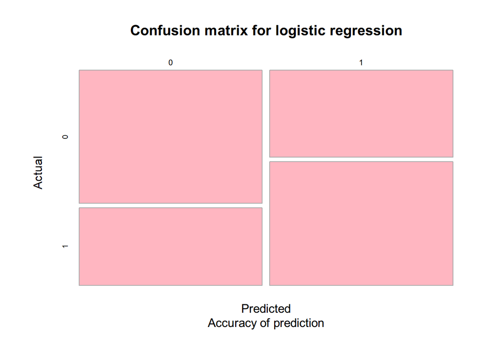

```r
#simple mosaic plot
mosaicplot(mosaic_table_lrm,
           main = "Confusion matrix for logistic regression",
           sub = "Accuracy of prediction",
           xlab = "Predicted",
           ylab = "Actual",
           color = "lightpink",
           border = "darkgrey")
```

### Experimental Machine Learning

```r
library(caret)

#Using the reduced dataset that already has removed highly correlated variables

aser_child_household_tib_2 <- aser_child_household_tib
glimpse(aser_child_household_tib_2)
```

```
## Rows: 1,494
## Columns: 8
## $ HouseholdCounter      <dbl> -0.6341124, -0.3088186, -0.2003874, -0.6341124, …
## $ EarningMembers        <dbl> -0.04889070, -0.04889070, -0.04889070, -0.048890…
## $ Car                   <dbl> 0.1651111, 0.1651111, 0.1651111, 0.1651111, -1.0…
## $ MotorCycle            <dbl> 0.008844786, 0.008844786, 0.008844786, 0.0088447…
## $ TravelTime            <dbl> -0.8089981, 1.9567757, 1.9567757, -0.8089981, -0…
## $ ClimateChange         <dbl> 1.17242588, -1.25530005, -1.25530005, -0.0414370…
## $ PsychologicalImpacted <dbl> 0.6167316, 0.6167316, 0.6167316, 0.6167316, 0.61…
## $ GeneralKnolwedge      <fct> Some_GK, Some_GK, Some_GK, Some_GK, Some_GK, Som…
```

```r
set.seed(123)

# Set up repeated k-fold cross-validation
train.control <- trainControl(method = "cv", number = 10) #10 fold cross validation

#the 10 fold CV stepwise model for logistic regression with stepwise!
logreg_cv10 <- train(GeneralKnolwedge ~ .,
                 data = aser_child_household_tib_2,
                 method="glmStepAIC", # Step wise AIC (estimator of prediction error) from maas package
                 direction="backward",
                 trControl = train.control,
                 family = "binomial")
```

[output not shown]

[output cut: 66 more lines]

[output not shown]

[output not shown]

[output not shown]

[output cut: 270 more lines]

[output not shown]

```r
logreg_cv10 #kappa and accuracy
```

```
## Generalized Linear Model with Stepwise Feature Selection
##
## 1494 samples
##    7 predictor
##    2 classes: 'No_GK', 'Some_GK'
##
## No pre-processing
## Resampling: Cross-Validated (10 fold)
## Summary of sample sizes: 1344, 1345, 1344, 1345, 1345, 1345, ...
## Resampling results:
##
##   Accuracy   Kappa
##   0.7402998  0.1190395
```

```r
summary(logreg_cv10) #estimates of the model. TravelTime is the only insignificant predictor.
```

```
##
## Call:
## NULL
##
## Coefficients:
##                       Estimate Std. Error z value Pr(>|z|)
## (Intercept)            1.05541    0.06258  16.865  < 2e-16 ***
## Car                    0.20238    0.08987   2.252 0.024333 *
## MotorCycle             0.26478    0.07292   3.631 0.000282 ***
## TravelTime            -0.09479    0.05961  -1.590 0.111830
## ClimateChange         -0.51730    0.07001  -7.389 1.48e-13 ***
## PsychologicalImpacted  0.26365    0.06726   3.920 8.85e-05 ***
## ---
## Signif. codes:  0 '***' 0.001 '**' 0.01 '*' 0.05 '.' 0.1 ' ' 1
##
## (Dispersion parameter for binomial family taken to be 1)
##
##     Null deviance: 1759.7  on 1493  degrees of freedom
## Residual deviance: 1656.0  on 1488  degrees of freedom
## AIC: 1668
##
## Number of Fisher Scoring iterations: 4
```

The model shows an accuracy of 74% meaning that the model correctly predicts a student exhibiting General Knowledge Score 74% of the time. The Kappa value is 0.11 which means that there is a poor/slight agreement between the actual and predicted values which means that there is room for improvement by selecting better parameters.

#### Predicted and Actual Values

```r
#get predicted values
predicted <- unname(logreg_cv10$finalModel$fitted.values) #change from a named number vector
#add predicted values to tibble
aser_child_household_tib_2$predicted.probabilities<-predicted

aser_child_household_tib_2 <- aser_child_household_tib_2 %>%
  mutate(actual = ifelse(GeneralKnolwedge == "No_GK", 0, 1)) %>%
  #assign 0 to .50 and less and 1 to anything else
  mutate(predicted = ifelse(predicted.probabilities < .50, 0, 1))

#both need to be factors
aser_child_household_tib_2$predicted <- as.factor(aser_child_household_tib_2$predicted)
aser_child_household_tib_2$actual <- as.factor(aser_child_household_tib_2$actual)

glimpse(aser_child_household_tib_2)
```

```
## Rows: 1,494
## Columns: 11
## $ HouseholdCounter        <dbl> -0.6341124, -0.3088186, -0.2003874, -0.6341124…
## $ EarningMembers          <dbl> -0.04889070, -0.04889070, -0.04889070, -0.0488…
## $ Car                     <dbl> 0.1651111, 0.1651111, 0.1651111, 0.1651111, -1…
## $ MotorCycle              <dbl> 0.008844786, 0.008844786, 0.008844786, 0.00884…
## $ TravelTime              <dbl> -0.8089981, 1.9567757, 1.9567757, -0.8089981, …
## $ ClimateChange           <dbl> 1.17242588, -1.25530005, -1.25530005, -0.04143…
## $ PsychologicalImpacted   <dbl> 0.6167316, 0.6167316, 0.6167316, 0.6167316, 0.…
## $ GeneralKnolwedge        <fct> Some_GK, Some_GK, Some_GK, Some_GK, Some_GK, S…
## $ predicted.probabilities <dbl> 0.6734772, 0.8478276, 0.8478276, 0.7944383, 0.…
## $ actual                  <fct> 1, 1, 1, 1, 1, 1, 0, 0, 1, 1, 1, 1, 0, 0, 1, 0…
## $ predicted               <fct> 1, 1, 1, 1, 1, 1, 1, 1, 1, 1, 1, 1, 1, 1, 1, 1…
```

```r
table(aser_child_household_tib_2$actual)
```

```
##
##    0    1
##  412 1082
```

```r
confusionMatrix(aser_child_household_tib_2$actual, aser_child_household_tib_2$predicted,
                mode = "everything",
                positive="1") #indicating some general knowledge
```

```
## Confusion Matrix and Statistics
##
##           Reference
## Prediction    0    1
##          0   47  365
##          1   25 1057
##
##                Accuracy : 0.739
##                  95% CI : (0.7159, 0.7611)
##     No Information Rate : 0.9518
##     P-Value [Acc > NIR] : 1
##
##                   Kappa : 0.1222
##
##  Mcnemar's Test P-Value : <2e-16
##
##             Sensitivity : 0.7433
##             Specificity : 0.6528
##          Pos Pred Value : 0.9769
##          Neg Pred Value : 0.1141
##               Precision : 0.9769
##                  Recall : 0.7433
##                      F1 : 0.8442
##              Prevalence : 0.9518
##          Detection Rate : 0.7075
##    Detection Prevalence : 0.7242
##       Balanced Accuracy : 0.6980
##
##        'Positive' Class : 1
##
```

### Second Mosaic Plot

```r
#put the actual and predicted values into a table
mosaic_table_caret <- table(aser_child_household_tib_2$actual, aser_child_household_tib_2$predicted)
mosaic_table_caret #check on that table
```

```
##
##        0    1
##   0   47  365
##   1   25 1057
```

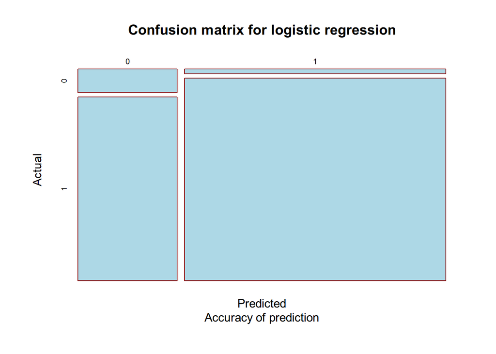

```r
#simple mosaic plot
mosaicplot(mosaic_table_caret,
           main = "Confusion matrix for logistic regression",
           sub = "Accuracy of prediction",
           xlab = "Predicted",
           ylab = "Actual",
           color = "lightblue",
           border = "darkred")
```

### Conclusion

The logistic regression model and the experimental machine learning model show that the model is not highly accurate in predicting the General Knowledge Score of the students based on our predictors. Part of the blame can be attributed to the class imbalance in the dataset to understand the predictors of the General Knowledge Score. The loss of data due to both, removal of NAs and undersampling, might have also contributed to the model’s poor performance.

The logistic regression model shows that the probability of the student exhibiting general knowledge increases to 63% when their parents exhibit some climate change awareness. This means that parental awareness of climate change can have a positive impact on the overall general knowledge of the students.

On the other hand, the probability of the student exhibiting general knowledge decreases to 44% when their parents report that they are psychologically impacted by climate change. This means that parental psychological impact due to climate change can have a negative impact on the overall general knowledge of the students.

In conclusion, the models can be improved by selecting better parameters and by using other machine learning techniques to address the class imbalances.